# WORKOUT PREDICTION WITH MACHINE LEARNING

Tommy Brant

February 3, 2019

```r
library(gbm)
library(AppliedPredictiveModeling)
library(caret)
library(randomForest)
```

## Executive Summary

The intent of this analysis is to build a model that can predict how well an exercise is performed based on the movements recorded. We work to tidy the data, find relevant variables, and build an accurate model. The model in this analysis is 98.63% accurate.

## Loading and PreProcessing the Data

Data links have been provided.

```r
#TRAINING SET
trainurl<-'https://d396qusza40orc.cloudfront.net/predmachlearn/pml-training.csv'

#DATA FOR QUIZ
testurl<-'https://d396qusza40orc.cloudfront.net/predmachlearn/pml-testing.csv'

#TRAINING + TEST DATA
download.file(trainurl, destfile = "TRAIN SET - CRS8PROJ.csv")
trainData = read.csv("TRAIN SET - CRS8PROJ.csv")


#VALIDATION SET FOR QUIZ
download.file(testurl, destfile = "VALIDATION SET - CRS8PROJ.csv")
validation = read.csv("VALIDATION SET - CRS8PROJ.csv")
```

Now, let’s split up our training set into a training and test set. Note the variable to be predicted is the type of workout, ‘classe’.

```r
set.seed(4321234)

#create training(75%) and testing(25%) sets
inTrain = createDataPartition(trainData$classe, p = 3/4)[[1]]
training = trainData[inTrain,]
testing = trainData[-inTrain,]
```

## Tidy the Data

Upon exploring the data, we find there are several variables with NA’s or missing values.

```r
##TESTS FOR MISSING VALUES/NA's
t1<-training
#Number of columns
length(t1[1,])
```

```
## [1] 160
```

```r
#Preliminary Look at first 20 columns
head(t1[1:20])
```

```
##   X user_name raw_timestamp_part_1 raw_timestamp_part_2   cvtd_timestamp
## 2 2  carlitos           1323084231               808298 05/12/2011 11:23
## 3 3  carlitos           1323084231               820366 05/12/2011 11:23
## 4 4  carlitos           1323084232               120339 05/12/2011 11:23
## 6 6  carlitos           1323084232               304277 05/12/2011 11:23
## 7 7  carlitos           1323084232               368296 05/12/2011 11:23
## 9 9  carlitos           1323084232               484323 05/12/2011 11:23
##   new_window num_window roll_belt pitch_belt yaw_belt total_accel_belt
## 2         no         11      1.41       8.07    -94.4                3
## 3         no         11      1.42       8.07    -94.4                3
## 4         no         12      1.48       8.05    -94.4                3
## 6         no         12      1.45       8.06    -94.4                3
## 7         no         12      1.42       8.09    -94.4                3
## 9         no         12      1.43       8.16    -94.4                3
##   kurtosis_roll_belt kurtosis_picth_belt kurtosis_yaw_belt
## 2
## 3
## 4
## 6
## 7
## 9
##   skewness_roll_belt skewness_roll_belt.1 skewness_yaw_belt max_roll_belt
## 2                                                                      NA
## 3                                                                      NA
## 4                                                                      NA
## 6                                                                      NA
## 7                                                                      NA
## 9                                                                      NA
##   max_picth_belt max_yaw_belt
## 2             NA
## 3             NA
## 4             NA
## 6             NA
## 7             NA
## 9             NA
```

```r
#Number of NAs for this variable
length(t1[,18][is.na(t1[,18])])
```

```
## [1] 14400
```

In our training set, there are 14718 entries, and 160 variables. Imputing the data with it’s variable mean or zeroes would be normally be considered, but it appears that more than 90% of the values are missing or NA. Thus, we are going to exclude these variables entirely for our model. Let’s work to find out what variables we need to exclude.

```r
##IDENTIFYING NA VALUES -AND- MISSING VALUES


#THIS FOR LOOP IDENTIFIES NA VALUES AND CORRESPONDING VARIABLES

#FIRST COLUMN WHERE NA's is 18
j<-rep.int(NA, length(t1))
for (i in 1:length(t1)){
  if (length(t1[,i][is.na(t1[,i])])>14000)
    j[i]<-i
}
#j # indices where variables should be avoided, otherwise, NA
#table(is.na(j)) #INDICATES 93 COLUMNS HAVE GOOD DATA; ALTERNATIVE 67 COLUMNS HAVE DATA TO BE IGNORED




#THIS FOR LOOP IDENTIFIES MISSING VALUES AND CORRESPONDING VARIABLES
k<-rep.int(NA, length(t1))  #length(k)

for (i in 8:159){ #8 THRU 159 B/C THOSE ARE THE APPLICABLE MEASUREMENTS
  if ((class(t1[,i]) == "factor" & length(t1[,i][is.na(as.numeric(as.character(t1[,12])))])>14000)){
    k[i]<-i
  }
}

#k # indices where variables should be avoided, otherwise, NA
#table(is.na(k)) #INDICATES 33 columns that have substantial missing data

#Tidy Data Set
t1.2<-t1[,(is.na(j) & is.na(k))]
length(t1.2)
```

```
## [1] 60
```

After filtering out the NA and Missing values, our data set now has 60 variables The first 7 columns appear to be indexing columns of sorts, and will remain in the data set, but not used for our model.

Given classe is a categorical variable, let’s use a random forest model to predict.

## Finding Impactful Variables to predict Classe

Next, we will need to identify what variables should be used to predict classe. We will accomplish this by looking at the Gini importance AKA Mean Decrease in Gini Impurity. This is effectively a measure of how important a variable is for estimating the value of the predicted variable across all of the trees that make up the forest. A higher Mean Decrease in Gini impurity indicates higher variable importance.

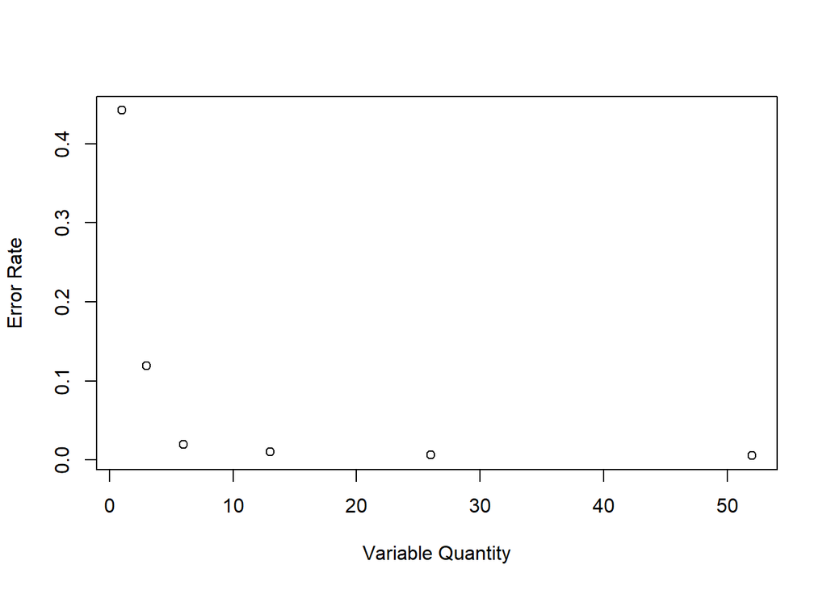

```r
#RANDOM FOREST CROSS VALIDATION
rfcv1<-rfcv(trainx=t1.2[,8:59], trainy=t1.2$classe, cv.fold=10) #10 FOLD CV

#visualize error rate -
plot(rfcv1$n.var, rfcv1$error.cv, xlab="Variable Quantity", ylab="Error Rate")
```

```r
#IMPORTANCE
rf2<-randomForest(classe ~ .,data=t1.2[8:60])
imp2<-importance(rf2, type=2)

#Unordered Data Frame of Variables and their importance
imp2.1.1<-data.frame(overall=as.numeric(imp2), names=rownames(imp2))

#ORDERED DATA FRAME
imp2.1.2<-imp2.1.1
imp2.1.2<-imp2.1.1[order(imp2.1.2$overall, decreasing=T),]
imp2.1.2
```

```
##      overall                names
## 1  933.46010            roll_belt
## 3  676.90656             yaw_belt
## 41 582.13591        pitch_forearm
## 39 564.44774    magnet_dumbbell_z
## 2  525.70243           pitch_belt
## 38 502.48742    magnet_dumbbell_y
## 40 459.78761         roll_forearm
## 37 371.69422    magnet_dumbbell_x
## 35 310.73257     accel_dumbbell_y
## 27 305.56228        roll_dumbbell
## 10 303.12255         accel_belt_z
## 13 287.67110        magnet_belt_z
## 12 274.07360        magnet_belt_y
## 36 244.36669     accel_dumbbell_z
```

[output cut: 38 more lines]

Note the list of variables ordered by their importance. Next, we filter by these variables in our training and testing data sets.

```r
#CORRESPOND THE 13 MOST IMPORTANT VARIABLES WITH OUR TRAINING DATA SET

t1.5<-t1.2[,1:7]
for (i in 1:13){
  t1.5<-cbind(t1.5,t1.2[,which(names(t1.2) == imp2.1.2$names[i])])
  names(t1.5)[7+i]<-as.character(imp2.1.2$names[i]) #CHANGE COL NAMES TO ORIG
}

t1.5<-cbind(t1.5, t1.2$classe) #ADD CLASSE VARIABLE AND DATA
names(t1.5)[21] <- "classe"


#NOW TO APPLY THIS TO OUR TESTING DATA SET
testing1.1<-testing[,1:7]
for (i in 1:13){
  testing1.1<-cbind(testing1.1,testing[,which(names(testing) == imp2.1.2$names[i])])
  names(testing1.1)[7+i]<-as.character(imp2.1.2$names[i]) #CHANGE COL NAMES TO ORIG
}
testing1.1<-cbind(testing1.1, testing$classe) #ADD CLASSE VARIABLE AND DATA
names(testing1.1)[21] <- "classe"
```

## Modeling and Cross Validation

```r
#Random Forest with Tunelength = 10, and K fold validation with 10 folds
model1.2<-train(as.factor(classe)~., method="rf", data=t1.5[,8:21], tuneLength=10, trControl=trainControl(method="cv", number=10))

print(model1.2) #SEE NOTES ABOVE REGARDIGN CONFUSION MATRIX, CROSS VALIDATION, ETC
```

```
## Random Forest
##
## 14718 samples
##    13 predictor
##     5 classes: 'A', 'B', 'C', 'D', 'E'
##
## No pre-processing
## Resampling: Cross-Validated (10 fold)
## Summary of sample sizes: 13245, 13247, 13248, 13246, 13247, 13245, ...
## Resampling results across tuning parameters:
##
##   mtry  Accuracy   Kappa
##    2    0.9838972  0.9796325
##    3    0.9860710  0.9823835
##    4    0.9862753  0.9826421
##    5    0.9857316  0.9819547
##    6    0.9853241  0.9814396
##    8    0.9845088  0.9804086
##    9    0.9836940  0.9793782
##   10    0.9832864  0.9788624
##   11    0.9822674  0.9775747
##   13    0.9777826  0.9719012
##
## Accuracy was used to select the optimal model using the largest value.
## The final value used for the model was mtry = 4.
```

```r
#print(model1.1$finalModel)
```

Note mtry accuracy is 98.63% accurate for our model with mtry = 4. Let’s use this model as a basis for prediction using the testing data set, and see what is the actual accuracy.

## Predicting Workout Type and Model Accuracy

```r
#PREDICT AGAINST TIDY TEST DATA
predrf1<-predict(model1.2, newdata=testing1.1)

#CONFUSION MATRIX TO COMPARE ACTUAL TO PREDICTED VALUES
confusionMatrix(predrf1,testing1.1$classe)
```

```
## Confusion Matrix and Statistics
##
##           Reference
## Prediction    A    B    C    D    E
##          A 1385    6    0    0    0
##          B    4  926    5    1    0
##          C    4   15  844   10    1
##          D    2    2    6  792    3
##          E    0    0    0    1  897
##
## Overall Statistics
##
##                Accuracy : 0.9878
##                  95% CI : (0.9843, 0.9907)
##     No Information Rate : 0.2845
##     P-Value [Acc > NIR] : < 2.2e-16
##
##                   Kappa : 0.9845
##  Mcnemar's Test P-Value : NA
##
## Statistics by Class:
##
##                      Class: A Class: B Class: C Class: D Class: E
## Sensitivity            0.9928   0.9758   0.9871   0.9851   0.9956
## Specificity            0.9983   0.9975   0.9926   0.9968   0.9998
## Pos Pred Value         0.9957   0.9893   0.9657   0.9839   0.9989
## Neg Pred Value         0.9972   0.9942   0.9973   0.9971   0.9990
## Prevalence             0.2845   0.1935   0.1743   0.1639   0.1837
## Detection Rate         0.2824   0.1888   0.1721   0.1615   0.1829
## Detection Prevalence   0.2836   0.1909   0.1782   0.1642   0.1831
## Balanced Accuracy      0.9956   0.9866   0.9899   0.9910   0.9977
```

The confusion matrix indicates our accuracy is 0.9877651, with out of sample error being 0.0122349. Let’s do a sanity check and compare this to our manual calculation.

```r
#OUT OF SAMPLE ERROR
OOSE.acc<-sum(predrf1==testing1.1$classe)/length(predrf1)

OOSE<-1-OOSE.acc
```

We calculate the out of sample error to be 0.0122349, which is consistent with the confusion matrix output.

## CITED REFERENCES

1. Velloso, E.; Bulling, A.; Gellersen, H.; Ugulino, W.; Fuks, H. Qualitative Activity Recognition of Weight Lifting Exercises. Proceedings of 4th International Conference in Cooperation with SIGCHI (Augmented Human ’13) . Stuttgart, Germany: ACM SIGCHI, 2013. (http://web.archive.org/web/20161224072740/http:/groupware.les.inf.puc-rio.br/har)

## CONCLUSION

```r
#Predicted Workout Types Against Validation data set
predrf2<-predict(model1.2, newdata=validation)
predrf2
```

```
##  [1] B A B A A E D B A A B C B A E E A B B B
## Levels: A B C D E
```